```python
# Copyright 2024 Google LLC
#
# Licensed under the Apache License, Version 2.0 (the "License");
# you may not use this file except in compliance with the License.
# You may obtain a copy of the License at
#
#     https://www.apache.org/licenses/LICENSE-2.0
#
# Unless required by applicable law or agreed to in writing, software
# distributed under the License is distributed on an "AS IS" BASIS,
# WITHOUT WARRANTIES OR CONDITIONS OF ANY KIND, either express or implied.
# See the License for the specific language governing permissions and
# limitations under the License.
```

[Run in Google Colab](https://colab.sandbox.google.com/github/https-deeplearning-ai/sc-gc-c4-gemini-public/blob/main/lesson-2/L2_colab_prompting_and_parameters.ipynb)

# Cost Estimate

The estimated cost for running this notebook once using your Google Cloud account, without the video segment (which has been converted to markdown), should be less than 0.10 USD (as of August 2024). Get the latest Gemini costs [here](https://cloud.google.com/vertex-ai/generative-ai/pricing).

# SETUP

This is follow up to the [How to Set Up your Google Cloud Account](https://learn.deeplearning.ai/courses/large-multimodal-model-prompting-with-gemini/lesson/9/how-to-set-up-your-google-cloud-account-%7C-try-it-out-yourself-%5Boptional%5D) instructions from the course, [Large Multimodal Model Prompting with Gemini](https://learn.deeplearning.ai/courses/large-multimodal-model-prompting-with-gemini/lesson/1/introduction) on the [Learning Platform](https://learn.deeplearning.ai) of [DeepLearning.AI](https://www.deeplearning.ai).

### Install Vertex AI SDK and other Required Packages

```python
%pip install --upgrade --user --quiet google-cloud-aiplatform
```

### Restart Runtime

To use the newly installed packages in this Jupyter runtime, you must restart the runtime. You can do this by running the cell below, which restarts the current kernel.

The restart might take a minute or longer. After it's restarted, continue to the next step.

```python
import IPython

app = IPython.Application.instance()
app.kernel.do_shutdown(True)
```

```
{'status': 'ok', 'restart': True}
```

[output not shown]

### Authenticate your Notebook Environment (Colab Only)

If you're running this notebook on Google Colab, run the cell below to authenticate your environment.

**NOTE:** The Gmail email address you use to authenticate this lesson colab must be the same as the one you used to set up your Google Cloud account and your Project.

```python
import sys

if "google.colab" in sys.modules:
    from google.colab import auth

    auth.authenticate_user()
```

### Set Google Cloud Project Information and Initialize Vertex AI SDK

**Add *your* Project ID below**, which you created while following the [How to Set Up your Google Cloud Account](https://learn.deeplearning.ai/courses/large-multimodal-model-prompting-with-gemini/lesson/9/how-to-set-up-your-google-cloud-account-%7C-try-it-out-yourself-%5Boptional%5D) instructions. If your `Project ID` was `dlai-shortcourse-on-gemini`, then you can run the cell below as it is. Otherwise, be sure to change it.

You can also look up your Project ID in your [Project Dashboard](https://console.cloud.google.com/projectselector2/home/dashboard).

```python
PROJECT_ID = "[PROJECT_ID]"  # @param {type:"string"}
LOCATION = "us-central1"  # @param {type:"string"}


import vertexai

vertexai.init(project=PROJECT_ID, location=LOCATION)
```

### Utils Functions and Images

**Important Note:**

If using Google Colab, all the

```
from utils import ...
```

functions and all required images are readily accessible in the notebook. Execute the following cells to proceed.

```python
import typing
import IPython.display
from PIL import Image as PIL_Image
from PIL import ImageOps as PIL_ImageOps

from vertexai.generative_models import (
    GenerationConfig,
    Image,
)

def gemini(prompt, model):
    responses = model.generate_content(prompt,
                                     stream=True)

    response_text = ""
    for response in responses:
        response_text += response.text

    return response_text

def display_images(
    images: typing.Iterable[Image],
    max_width: int = 600,
    max_height: int = 350,
) -> None:
    for image in images:
        pil_image = typing.cast(PIL_Image.Image, image._pil_image)
        if pil_image.mode != "RGB":
            # RGB is supported by all Jupyter environments (e.g. RGBA is not yet)
            pil_image = pil_image.convert("RGB")
        image_width, image_height = pil_image.size
        if max_width < image_width or max_height < image_height:
            # Resize to display a smaller notebook image
            pil_image = PIL_ImageOps.contain(pil_image, (max_width, max_height))
        IPython.display.display(pil_image)

def print_multimodal_prompt(contents: list):
    """
    Given contents that would be sent to Gemini,
    output the full multimodal prompt for ease of readability.
    """
    for content in contents:
        if isinstance(content, Image):
            display_images([content])
        elif isinstance(content, Part):
            url = get_url_from_gcs(content.file_data.file_uri)
            IPython.display.display(load_image_from_url(url))
        else:
            print(content)

def gemini_vision(contents_image, model):

    responses = model.generate_content(
        contents_image,
        stream=True)

    response_text = ""
    for response in responses:
        response_text += response.text
    return response_text

def gemini_vision_parameters(contents_image, model, config):

    responses = model.generate_content(
        contents=contents_image,
        generation_config=config,
        stream=True
    )

    response_text = ""
    for response in responses:
        response_text += response.text

    return response_text
```

```python
# download images from bucket
! gsutil cp "gs://dlai-sc-gemini-bucket/Andrew_power_tools.png" ./andrew_power_tools.png
! gsutil cp "gs://dlai-sc-gemini-bucket/panda.png" ./panda.png
```

```
/bin/bash: gsutil: command not found
/bin/bash: gsutil: command not found
```

# IN COURSE VIDEO

Lesson video starts from below.

# [Lesson 2: Multimodal Prompting and Parameter Control](https://learn.deeplearning.ai/courses/large-multimodal-model-prompting-with-gemini/lesson/3/multimodal-prompting-and-parameter-control)

In this notebook, you'll have a quick overview of simple text, image and video examples with Gemini, and learn about different Parameters which can be set up.

## Text Examples

- Load the [gemini-1.0-pro-002](https://console.cloud.google.com/vertex-ai/publishers/google/model-garden/gemini-pro) model.

```python
from vertexai.generative_models import GenerativeModel
```

```python
model = GenerativeModel("gemini-1.0-pro-002")
```

```python
from utils import gemini
```

**Note**: LLM's do not always produce the same results, especially because they are frequently updated. So the output you see in the video might be different than what you may get.

If you run the next cell and receive a `403 error`:

- Recheck your project name, and be sure it matches the name assigned when setting up the Google Cloud Project. Note that project names are lowercase.
- Ensure you completed Step 5 of the instructions on setting up Google Cloud and Vertex AI.

```python
gemini("What is a multimodal model?", model=model)
```

```
'A multimodal model is a type of artificial intelligence (AI) model that can process and understand multiple types of data, such as text, images, and videos. This makes them more versatile and powerful than traditional AI models that can only process one type of data. Multimodal models are used for …
```

#### Under the hood of the helper functions

```python
prompt_1 = """
In short, what is deeplearning.ai,
and what can it offer me as a Machine Learning Engineer?"
"""
```

- `stream=True` processes the response as it being generated.
- With `stream=False`, you have to wait until the entire response has been generated before it can be proccessed and printed.

```python
response_1 = model.generate_content(prompt_1, stream=True)
```

```python
response_1
```

```
<generator object _GenerativeModel._generate_content_streaming at 0x7f355ce99f20>
```

**Note**: LLM's do not always produce the same results, especially because they are frequently updated. So the output you see in the video might be different than what you may get.

```python
for response in response_1:
    print(response)
```

```
candidates {
  content {
    role: "model"
    parts {
      text: "##"
    }
  }
}
model_version: "gemini-1.0-pro-002"

candidates {
  content {
    role: "model"
    parts {
      text: " Deeplearning.ai in a Nutshell\n\nDeeplearning.ai is an online platform that"
    }
  }
  safety_ratings {
    category: HARM_CATEGORY_HATE_SPEECH
    probability: NEGLIGIBLE
    probability_score: 0.0942382812
    severity: HARM_SEVERITY_NEGLIGIBLE
    severity_score: 0.0756835938
  }
  safety_ratings {
    category: HARM_CATEGORY_DANGEROUS_CONTENT
    probability: NEGLIGIBLE
    probability_score: 0.123535156
    severity: HARM_SEVERITY_NEGLIGIBLE
    severity_score: 0.138671875
  }
  safety_ratings {
    category: HARM_CATEGORY_HARASSMENT
    probability: NEGLIGIBLE
    probability_score: 0.188476562
    severity: HARM_SEVERITY_NEGLIGIBLE
    severity_score: 0.123535156
  }
  safety_ratings {
    category: HARM_CATEGORY_SEXUALLY_EXPLICIT
```

[output cut: 426 more lines]

```
candidates {
  content {
    role: "model"
    parts {
      text: ""
    }
  }
  finish_reason: STOP
}
usage_metadata {
  prompt_token_count: 25
  candidates_token_count: 543
  total_token_count: 568
}
model_version: "gemini-1.0-pro-002"
```

```python
response_1 = model.generate_content(prompt_1,
                                     stream=True)
```

```python
for response in response_1:
    print(response.text)
```

```
##
 Deeplearning.ai in a Nutshell

Deeplearning.ai, founded by
 Andrew Ng, focuses on online education about deep learning and artificial intelligence. They provide
 various resources, including:

* **Courses:** Deeplearning.ai offers a range of courses, from introductory to advanced, covering topics like deep learning fundamentals,
 computer vision, and natural language processing. These courses are taught by industry experts and offer hands-on learning through coding assignments and projects.
* **Specializations:** Deeplearning
.ai also provides specializations, which are groups of related courses designed to help learners gain mastery in a specific area. For example, they offer a deep learning specialization and an AI for business specialization.
* **Content:** Beyond courses,
 deeplearning.ai offers a wealth of free content, including blog posts, articles, and videos on various deep learning and AI topics.

## What Deeplearning.ai Offers Machine Learning Engineers:

* **Upskilling:** For Machine Learning Engineers who
 want to stay current with the latest advancements in deep learning, deeplearning.ai offers a variety of resources to help them learn new skills and techniques.
* **Specialization:** The specializations offered by deeplearning.ai can help Machine Learning Engineers gain deeper expertise in specific areas of deep learning, making them more valuable to
 potential employers.
* **Career Advancement:** By completing courses and specializations offered by deeplearning.ai, Machine Learning Engineers can demonstrate their commitment to professional development and increase their chances of landing better jobs or promotions.

However, it's important to note that deeplearning.ai is just one resource among many available for Machine Learning
 Engineers. Other platforms like Coursera, Udacity, and fast.ai also have a wide variety of courses and programs on deep learning and AI.

Here are some additional points to consider:

* **Cost:** While some of the content on deeplearning.ai is free, most of the courses and specializations
 require a paid subscription.
* **Time commitment:** Completing a course or specialization on deeplearning.ai requires a significant time investment.
* **Prerequisites:** Some of the more advanced courses on deeplearning.ai require prior knowledge of machine learning and Python programming.

Ultimately, whether or not deeplearning.ai is
 right for you as a Machine Learning Engineer depends on your individual needs and learning goals.

I hope this helps! Let me know if you have any other questions.
```

## Multimodality: Image + Text

```python
from vertexai.generative_models import (
    GenerativeModel,
    Image,
    Part,
)
```

- Load the [gemini-1.0-pro-vision-001](https://console.cloud.google.com/vertex-ai/publishers/google/model-garden/gemini-pro-vision) model.

```python
multimodal_model = GenerativeModel("gemini-1.0-pro-vision-001")
```

- Load a prompt and an image

```python
image = Image.load_from_file("wuxia.jpg")
```

```python
prompt_3 = "Please describe what is in this image?"

# prompt_3 = "What are likely professions of this person?"
```

```python
contents_image = [image, prompt_3]
```

```
-------Prompt--------
```

[figure not shown]

```
Please describe what is in this image?
```

```python
# from utils import print_multimodal_prompt

print("-------Prompt--------")
print_multimodal_prompt(contents_image)
```

**Note**: LLM's do not always produce the same results, especially because they are frequently updated. So the output you see in the video might be different than what you may get.

```python
# from utils import gemini_vision

gemini_vision(contents_image, model=multimodal_model)
```

```
' The image contains a fight scene between a group of people. They are all wearing traditional Japanese clothing and are armed with swords. The background is a blur of black and white, which suggests that the fight is taking place in a dark and shadowy environment.'
```

## Multimodality: Video + Text

- Load a video and a prompt.
- The video loads from a GCP bucket.

```python
video_uri = "gs://cicisnow/gesture.mp4"
video_url = "https://storage.googleapis.com/cicisnow/gesture.mp4"

from IPython.display import Video
Video(video_url, width=450)
```

[video not shown]

```python
prompt = """
Answer the following questions using the video only:
 - What is the main character in this video?
 - What is the main character doing?
 - Where is the main character located?
"""
```

```python
video = Part.from_uri(video_uri, mime_type="video/mp4")
contents_video = [prompt, video]
```

```python
responses_4 = multimodal_model.generate_content(contents_video, stream=True)
```

[output not shown]

**Note**: LLM's do not always produce the same results, especially because they are frequently updated. So the output you see in the video might be different than what you may get.

```python
for response in responses_4:
    print(response.text, end="")
```

```
 - The main character is a young woman named Jamie.
- She is sitting in an office, working on her computer.
- She is wearing a casual outfit, and she has her hair in a ponytail.
```

## Gemini Model Parameters

- Load an image.
- You'll be using the [gemini-1.0-pro-vision-001](https://console.cloud.google.com/vertex-ai/publishers/google/model-garden/gemini-pro-vision) model.
- First run the model using its *default parameters*.

```python
image_1 = Image.load_from_file("soup_noodle.jpg")
```

```python
prompt_1 = """Write what is happening in the following image
from a unique perspective and do not mention names"""
```

```python
contents = [image_1, prompt_1]
```

```
-------Prompt--------
```

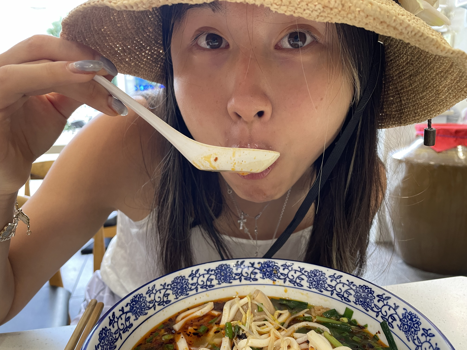

```
Write what is happening in the following image
from a unique perspective and do not mention names
```

```python
# from utils import print_multimodal_prompt

print("-------Prompt--------")
print_multimodal_prompt(contents)
```

```python
response_1 = multimodal_model.generate_content(
    contents,
    stream=True
)
```

**Note**: LLM's do not always produce the same results, especially because they are frequently updated. So the output you see in the video might be different than what you may get.

```python
for response in response_1:
    print(response.text, end="")
```

```
 A young woman is eating a bowl of spicy noodles. She is slurping the noodles and has a spoonful of them in her mouth. She is wearing a straw hat and a white shirt. She is sitting at a table in a restaurant.
```

### Temperature, Top k

- GenerationConfig lets you set up the parameters for the model.

**Note:** In the latest version, `from vertexai.preview.generative_models` has been changed to `from vertexai.generative_models`.

`from vertexai.preview.generative_models` can still be used.

```python
from vertexai.generative_models import GenerationConfig
```

```python
# from utils import gemini_vision_parameters
```

- Setting `temperature=0.0` and `top_k=1`

```python
generation_config_1 = GenerationConfig(
    temperature=0.0,
    top_k=1,
)
```

```python
response_zero_temp = gemini_vision_parameters(
                        contents,
                        multimodal_model,
                        generation_config_1)
```

**Note**: LLM's do not always produce the same results, especially because they are frequently updated. So the output you see in the video might be different than what you may get.

```python
print(response_zero_temp)
```

```
 A young woman is eating a bowl of soup. She is using a spoon to scoop the soup from the bowl and bring it to her mouth. She is wearing a straw hat and a white shirt. She is sitting at a table in a restaurant.
```

```python
responses_zero_temp = gemini_vision_parameters(
                        contents,
                        multimodal_model,
                        generation_config_1)

print(response_zero_temp)
```

```
 A young woman is eating a bowl of soup. She is using a spoon to scoop the soup from the bowl and bring it to her mouth. She is wearing a straw hat and a white shirt. She is sitting at a table in a restaurant.
```

- Setting `temperature=1` and `top_k=40`

```python
generation_config_2 = GenerationConfig(
    temperature=1,
    top_k=40,
)
```

```python
responses_high_temp_topk = gemini_vision_parameters(
                            contents,
                            multimodal_model,
                            generation_config_2)
```

**Note**: LLM's do not always produce the same results, especially because they are frequently updated. So the output you see in the video might be different than what you may get.

```python
print(responses_high_temp_topk)
```

```
 As I approach the table, I see her sitting there, waiting for me. She is wearing a beautiful dress and her hair is done up in a way that makes her look even more stunning. I can't help but feel lucky to be here with her.

We ordered some food and as we wait I can't help but admire the way she eats. She is so graceful and elegant, even when she's eating something as simple as soup.

The food was delicious, and it was made even better by the experience of sharing it with her.
```

### Top p

- Setting `top_p=0.01`, and maintaining `temperature=1`, `top_k=40`

```python
generation_config_4 = GenerationConfig(
    temperature=1,
    top_k=40,
    top_p=0.01,
)
```

**Note**: LLM's do not always produce the same results, especially because they are frequently updated. So the output you see in the video might be different than what you may get.

```python
responses_high_temp_topp = gemini_vision_parameters(
                            contents,
                            multimodal_model,
                            generation_config_4)

print(responses_high_temp_topp)
```

```
 A young woman is eating a bowl of soup. She is using a spoon to scoop the soup from the bowl and bring it to her mouth. She is wearing a straw hat and a white shirt. She is sitting at a table in a restaurant.
```

### Max Output Tokens

- The range for `max_output_tokens` is `1 (inclusive) to 2049 (exclusive)`
- When using `max_output_tokens`, the number of words returned by the model are 1 less than what you specify.
- So setting `max_output_tokens` to `1` will throw an error, since there would be no generated text.

```python
generation_config_5 = GenerationConfig(
    max_output_tokens=10,
)
```

**Note**: LLM's do not always produce the same results, especially because they are frequently updated. So the output you see in the video might be different than what you may get.

```python
responses_max_output = gemini_vision_parameters(
                        contents,
                        multimodal_model,
                        generation_config_5)

print(responses_max_output)
```

```
 A young woman is eating a bowl of soup
```

### Stop Sequences

- The range for `stop_sequences` is `1 (inclusive) to 17 (exclusive)`
- Multiple (no more than 16) words, numbers, space or special characters can be passed as a `list`.
- The model response stops *just before* the *first time* it encounters any stop sequence.

```python
generation_config_6 = GenerationConfig(
    stop_sequences=["panda"]
)
```

**Note**: LLM's do not always produce the same results, especially because they are frequently updated. So the output you see in the video might be different than what you may get.

```python
responses_stop = gemini_vision_parameters(
                    contents,
                    multimodal_model,
                    generation_config_6)

print(responses_stop)
```

```
 A young woman is eating a bowl of soup with chopsticks. She is wearing a straw hat and a white shirt. She is sitting at a table in a restaurant.
```